# Ch18_Expressions-1

Min-Yao

2023-07-12

# 18 Expressions

## 18.1 Introduction

To compute on the language, we first need to understand its structure. That requires some new vocabulary, some new tools, and some new ways of thinking about R code. The first of these is the distinction between an operation and its result. Take the following code, which multiplies a variable `x` by 10 and saves the result to a new variable called `y`. It doesn’t work because we haven’t defined a variable called `x`:

```r
y <- x * 10
```

```
## Error in eval(expr, envir, enclos): object 'x' not found
```

It would be nice if we could capture the intent of the code without executing it. In other words, how can we separate our description of the action from the action itself?

One way is to use `rlang::expr()`:

```r
z <- rlang::expr(y <- x * 10)
z
```

```
## y <- x * 10
```

`expr()` returns an expression, an object that captures the structure of the code without evaluating it (i.e. running it). If you have an expression, you can evaluate it with `base::eval()`:

```r
x <- 4
eval(z)
y
```

```
## [1] 40
```

The focus of this chapter is the data structures that underlie expressions. Mastering this knowledge will allow you to inspect and modify captured code, and to generate code with code. We’ll come back to `expr()` in Chapter @ref(quasiquotation), and to `eval()` in Chapter @ref(evaluation).

### Outline

- Section @ref(ast) introduces the idea of the abstract syntax tree (AST), and reveals the tree like structure that underlies all R code.
- Section @ref(expression-details) dives into the details of the data structures that underpin the AST: constants, symbols, and calls, which are collectively known as expressions.
- Section @ref(grammar) covers parsing, the act of converting the linear sequence of character in code into the AST, and uses that idea to explore some details of R’s grammar.
- Section @ref(ast-funs) shows you how you can use recursive functions to compute on the language, writing functions that compute with expressions.
- Section @ref(expression-special) circles back to three more specialised data structures: pairlists, missing arguments, and expression vectors.

### Prerequisites

Make sure you’ve read the metaprogramming overview in Chapter @ref(meta-big-picture) to get a broad overview of the motivation and the basic vocabulary. You’ll also need the [rlang](https://rlang.r-lib.org) package to capture and compute on expressions, and the [lobstr](https://lobstr.r-lib.org) package to visualise them.

```r
library(rlang)
library(lobstr)
```

## 18.2 Abstract syntax trees

Expressions are also called **abstract syntax trees** (ASTs) because the structure of code is hierarchical and can be naturally represented as a tree. Understanding this tree structure is crucial for inspecting and modifying expressions (i.e. metaprogramming).

### 18.2.1 Drawing

We’ll start by introducing some conventions for drawing ASTs, beginning with a simple call that shows their main components: `f(x, "y", 1)`. I’ll draw trees in two ways[^1]:

- By “hand” (i.e. with OmniGraffle):

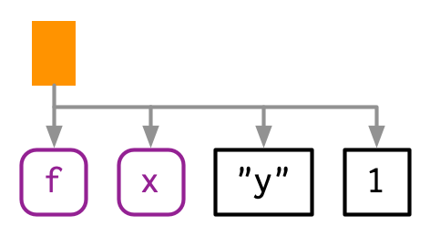

- With `lobstr::ast()`:

  ```r
  lobstr::ast(f(x, "y", 1))
  ```

  ```
  ## █─f
  ## ├─x
  ## ├─"y"
  ## └─1
  ```

Both approaches share conventions as much as possible:

- The leaves of the tree are either symbols, like `f` and `x`, or constants, like `1` or `"y"`. Symbols are drawn in purple and have rounded corners. Constants have black borders and square corners. Strings and symbols are easily confused, so strings are always surrounded in quotes.
- The branches of the tree are call objects, which represent function calls, and are drawn as orange rectangles. The first child (`f`) is the function that gets called; the second and subsequent children (`x`, `"y"`, and `1`) are the arguments to that function.

Colours will be shown when *you* call `ast()`, but do not appear in the book for complicated technical reasons.

The above example only contained one function call, making for a very shallow tree. Most expressions will contain considerably more calls, creating trees with multiple levels. For example, consider the AST for `f(g(1, 2), h(3, 4, i()))`:

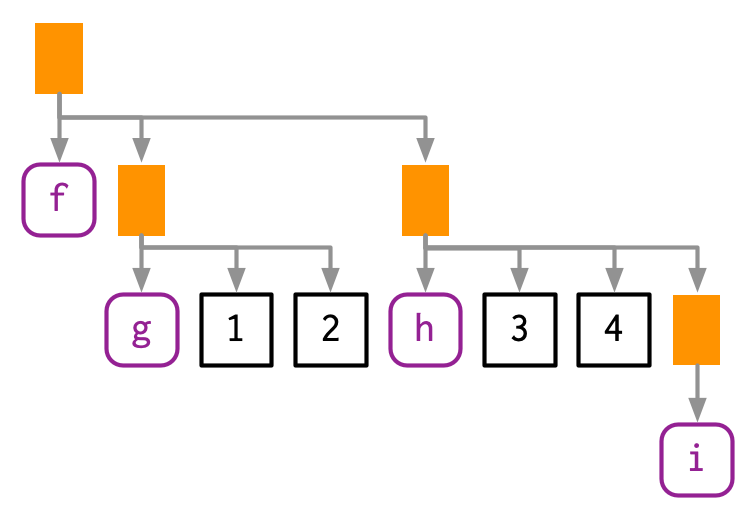

```r
lobstr::ast(f(g(1, 2), h(3, 4, i())))
```

```
## █─f
## ├─█─g
## │ ├─1
## │ └─2
## └─█─h
##   ├─3
##   ├─4
##   └─█─i
```

You can read the hand-drawn diagrams from left-to-right (ignoring vertical position), and the lobstr-drawn diagrams from top-to-bottom (ignoring horizontal position). The depth within the tree is determined by the nesting of function calls. This also determines evaluation order, as evaluation generally proceeds from deepest-to-shallowest, but this is not guaranteed because of lazy evaluation (Section @ref(lazy-evaluation)). Also note the appearance of `i()`, a function call with no arguments; it’s a branch with a single (symbol) leaf.

### 18.2.2 Non-code components

You might have wondered what makes these *abstract* syntax trees. They are abstract because they only capture important structural details of the code, not whitespace or comments:

```r
ast(
  f(x,  y)  # important!
)
```

```
## █─f
## ├─x
## └─y
```

There’s only one place where whitespace affects the AST:

```r
lobstr::ast(y <- x)
```

```
## █─`<-`
## ├─y
## └─x
```

```r
lobstr::ast(y < -x)
```

```
## █─`<`
## ├─y
## └─█─`-`
##   └─x
```

### 18.2.3 Infix calls

Every call in R can be written in tree form because any call can be written in prefix form (Section @ref(prefix-transform)). Take `y <- x * 10` again: what are the functions that are being called? It is not as easy to spot as `f(x, 1)` because this expression contains two infix calls: `<-` and `*`. That means that these two lines of code are equivalent:

```r
y <- x * 10
`<-`(y, `*`(x, 10))
```

And they both have this AST[^2]:

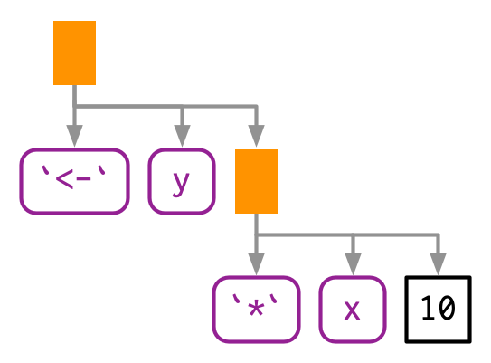

```r
lobstr::ast(y <- x * 10)
```

```
## █─`<-`
## ├─y
## └─█─`*`
##   ├─x
##   └─10
```

There really is no difference between the ASTs, and if you generate an expression with prefix calls, R will still print it in infix form:

```r
expr(`<-`(y, `*`(x, 10)))
```

```
## y <- x * 10
```

> The order in which infix operators are applied is governed by a set of rules called operator precedence, and we’ll use `lobstr::ast()` to explore them in Section @ref(operator-precedence).

### 18.2.4 Exercises

1. Reconstruct the code represented by the trees below:

   ```
   ## █─f
   ## └─█─g
   ##   └─█─h
   ```

   ```
   ## █─`+`
   ## ├─█─`+`
   ## │ ├─1
   ## │ └─2
   ## └─3
   ```

   ```
   ## █─`*`
   ## ├─█─`(`
   ## │ └─█─`+`
   ## │   ├─x
   ## │   └─y
   ## └─z
   ```

```r
ast(f(g(h())))
```

```
## █─f
## └─█─g
##   └─█─h
```

```r
ast(1 + 2 + 3)
```

```
## █─`+`
## ├─█─`+`
## │ ├─1
## │ └─2
## └─3
```

```r
ast((x + y) * z)
```

```
## █─`*`
## ├─█─`(`
## │ └─█─`+`
## │   ├─x
## │   └─y
## └─z
```

2. Draw the following trees by hand and then check your answers with `lobstr::ast()`.

   ```r
   f(g(h(i(1, 2, 3))))
   f(1, g(2, h(3, i())))
   f(g(1, 2), h(3, i(4, 5)))
   ```

```r
ast(f(g(h(i(1, 2, 3)))))
```

```
## █─f
## └─█─g
##   └─█─h
##     └─█─i
##       ├─1
##       ├─2
##       └─3
```

```r
ast(f(1, g(2, h(3, i()))))
```

```
## █─f
## ├─1
## └─█─g
##   ├─2
##   └─█─h
##     ├─3
##     └─█─i
```

```r
ast(f(g(1, 2), h(3, i(4, 5))))
```

```
## █─f
## ├─█─g
## │ ├─1
## │ └─2
## └─█─h
##   ├─3
##   └─█─i
##     ├─4
##     └─5
```

3. What’s happening with the ASTs below? (Hint: carefully read `?"^"`.)

   ```r
   lobstr::ast(`x` + `y`)
   ```

   ```
   ## █─`+`
   ## ├─x
   ## └─y
   ```

   ```r
   lobstr::ast(x ** y)
   ```

   ```
   ## █─`^`
   ## ├─x
   ## └─y
   ```

   ```r
   lobstr::ast(1 -> x)
   ```

   ```
   ## █─`<-`
   ## ├─x
   ## └─1
   ```

   > ASTs initiate function calls by stating the function’s name, resulting in the transformation of the first expression into its prefix form. The second scenario involves the translation of `**` into `^` by R’s parser. Lastly, in the final AST, R reconfigures the expression by flipping it during parsing.
4. What is special about the AST below? (Hint: re-read Section @ref(fun-components).)

   ```r
   lobstr::ast(function(x = 1, y = 2) {})
   ```

   ```
   ## █─`function`
   ## ├─█─x = 1
   ## │ └─y = 2
   ## ├─█─`{`
   ## └─<inline srcref>
   ```

> The final leaf of the AST lacks explicit mention within the expression. Rather, base R automatically generates the srcref attribute, which indicates the source code of the function.
5. What does the call tree of an `if` statement with multiple `else if` conditions look like? Why?

```r
x <- 0
if (x < 0) {
  print("Negative number")
} else if (x > 0) {
  print("Positive number")
} else
  print("Zero")
```

```
## [1] "Zero"
```

```r
ast(if (x < 0) {
  print("Negative number")
} else if (x > 0) {
  print("Positive number")
} else
  print("Zero"))
```

```
## █─`if`
## ├─█─`<`
## │ ├─x
## │ └─0
## ├─█─`{`
## │ └─█─print
## │   └─"Negative number"
## └─█─`if`
##   ├─█─`>`
##   │ ├─x
##   │ └─0
##   ├─█─`{`
##   │ └─█─print
##   │   └─"Positive number"
##   └─█─print
##     └─"Zero"
```

```r
ast(if (x < 0)
  print("Negative number")
  else if (x > 0)
    print("Positive number")
  else
    print("Zero"))
```

```
## █─`if`
## ├─█─`<`
## │ ├─x
## │ └─0
## ├─█─print
## │ └─"Negative number"
## └─█─`if`
##   ├─█─`>`
##   │ ├─x
##   │ └─0
##   ├─█─print
##   │ └─"Positive number"
##   └─█─print
##     └─"Zero"
```

## 18.3 Expressions

> Collectively, the data structures present in the AST are called expressions. An **expression** is any member of the set of base types created by parsing code: constant scalars, symbols, call objects, and pairlists. These are the data structures used to represent captured code from `expr()`, and `is_expression(expr(...))` is always true[^3]. Constants, symbols and call objects are the most important, and are discussed below. Pairlists and empty symbols are more specialised and we’ll come back to them in Sections @ref(pairlists) and Section @ref(empty-symbol).

> NB: In base R documentation “expression” is used to mean two things. As well as the definition above, expression is also used to refer to the type of object returned by `expression()` and `parse()`, which are basically lists of expressions as defined above. In this book I’ll call these **expression vectors**, and I’ll come back to them in Section @ref(expression-vectors).

### 18.3.1 Constants

Scalar constants are the simplest component of the AST. More precisely, a **constant** is either `NULL` or a length-1 atomic vector (or scalar, Section @ref(scalars)) like `TRUE`, `1L`, `2.5` or `"x"`. You can test for a constant with `rlang::is_syntactic_literal()`.

Constants are self-quoting in the sense that the expression used to represent a constant is the same constant:

```r
identical(expr(TRUE), TRUE)
```

```
## [1] TRUE
```

```r
identical(expr(1), 1)
```

```
## [1] TRUE
```

```r
identical(expr(2L), 2L)
```

```
## [1] TRUE
```

```r
identical(expr("x"), "x")
```

```
## [1] TRUE
```

### 18.3.2 Symbols

> A **symbol** represents the name of an object like `x`, `mtcars`, or `mean`. In base R, the terms symbol and name are used interchangeably (i.e. `is.name()` is identical to `is.symbol()`), but in this book I used symbol consistently because “name” has many other meanings.

You can create a symbol in two ways: by capturing code that references an object with `expr()`, or turning a string into a symbol with `rlang::sym()`:

```r
expr(x)
```

```
## x
```

```r
sym("x")
```

```
## x
```

You can turn a symbol back into a string with `as.character()` or `rlang::as_string()`. `as_string()` has the advantage of clearly signalling that you’ll get a character vector of length 1.

```r
as_string(expr(x))
```

```
## [1] "x"
```

You can recognise a symbol because it’s printed without quotes, `str()` tells you that it’s a symbol, and `is.symbol()` is `TRUE`:

```r
str(expr(x))
```

```
##  symbol x
```

```r
is.symbol(expr(x))
```

```
## [1] TRUE
```

The symbol type is not vectorised, i.e. a symbol is always length 1. If you want multiple symbols, you’ll need to put them in a list, using (e.g.) `rlang::syms()`.

### 18.3.3 Calls

> A **call object** represents a captured function call. Call objects are a special type of list[^4] where the first component specifies the function to call (usually a symbol), and the remaining elements are the arguments for that call. Call objects create branches in the AST, because calls can be nested inside other calls.

You can identify a call object when printed because it looks just like a function call. Confusingly `typeof()` and `str()` print “language”[^5] for call objects, but `is.call()` returns `TRUE`:

```r
lobstr::ast(read.table("important.csv", row.names = FALSE))
```

```
## █─read.table
## ├─"important.csv"
## └─row.names = FALSE
```

```r
x <- expr(read.table("important.csv", row.names = FALSE))

typeof(x)
```

```
## [1] "language"
```

```r
is.call(x)
```

```
## [1] TRUE
```

#### 18.3.3.1 Subsetting

Calls generally behave like lists, i.e. you can use standard subsetting tools. The first element of the call object is the function to call, which is usually a symbol:

```r
x[[1]]
```

```
## read.table
```

```r
is.symbol(x[[1]])
```

```
## [1] TRUE
```

The remainder of the elements are the arguments:

```r
as.list(x[-1])
```

```
## [[1]]
## [1] "important.csv"
##
## $row.names
## [1] FALSE
```

You can extract individual arguments with `[[` or, if named, `$`:

```r
x[[2]]
```

```
## [1] "important.csv"
```

```r
x$row.names
```

```
## [1] FALSE
```

You can determine the number of arguments in a call object by subtracting 1 from its length:

```r
length(x) - 1
```

```
## [1] 2
```

Extracting specific arguments from calls is challenging because of R’s flexible rules for argument matching: it could potentially be in any location, with the full name, with an abbreviated name, or with no name. To work around this problem, you can use `rlang::call_standardise()` which standardises all arguments to use the full name:

```r
rlang::call_standardise(x)
```

```
## read.table(file = "important.csv", row.names = FALSE)
```

(NB: If the function uses `...` it’s not possible to standardise all arguments.)

Calls can be modified in the same way as lists:

```r
x$header <- TRUE
x
```

```
## read.table("important.csv", row.names = FALSE, header = TRUE)
```

#### 18.3.3.2 Function position

> The first element of the call object is the **function position**. This contains the function that will be called when the object is evaluated, and is usually a symbol[^6]:

```r
lobstr::ast(foo())
```

```
## █─foo
```

While R allows you to surround the name of the function with quotes, the parser converts it to a symbol:

```r
lobstr::ast("foo"())
```

```
## █─foo
```

However, sometimes the function doesn’t exist in the current environment and you need to do some computation to retrieve it: for example, if the function is in another package, is a method of an R6 object, or is created by a function factory. In this case, the function position will be occupied by another call:

```r
lobstr::ast(pkg::foo(1))
```

```
## █─█─`::`
## │ ├─pkg
## │ └─foo
## └─1
```

```r
lobstr::ast(obj$foo(1))
```

```
## █─█─`$`
## │ ├─obj
## │ └─foo
## └─1
```

```r
lobstr::ast(foo(1)(2))
```

```
## █─█─foo
## │ └─1
## └─2
```

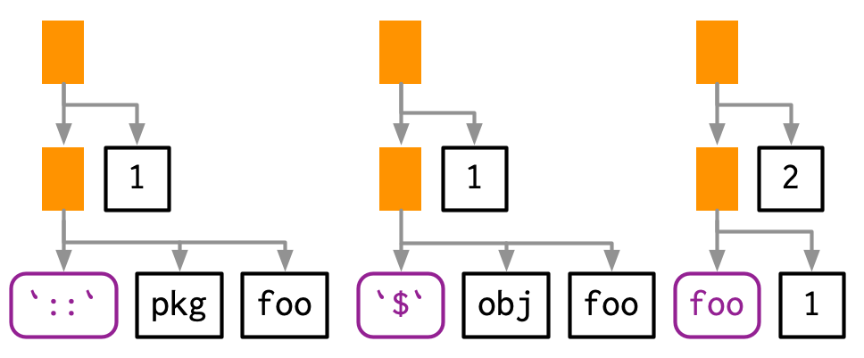

#### 18.3.3.3 Constructing

You can construct a call object from its components using `rlang::call2()`. The first argument is the name of the function to call (either as a string, a symbol, or another call). The remaining arguments will be passed along to the call:

```r
call2("mean", x = expr(x), na.rm = TRUE)
```

```
## mean(x = x, na.rm = TRUE)
```

```r
call2(expr(base::mean), x = expr(x), na.rm = TRUE)
```

```
## base::mean(x = x, na.rm = TRUE)
```

Infix calls created in this way still print as usual.

```r
call2("<-", expr(x), 10)
```

```
## x <- 10
```

Using `call2()` to create complex expressions is a bit clunky. You’ll learn another technique in Chapter @ref(quasiquotation).

### 18.3.4 Summary

The following table summarises the appearance of the different expression subtypes in `str()` and `typeof()`:

|  | `str()` | `typeof()` |
| --- | --- | --- |
| Scalar constant | `logi`/`int`/`num`/`chr` | `logical`/`integer`/`double`/`character` |
| Symbol | `symbol` | `symbol` |
| Call object | `language` | `language` |
| Pairlist | Dotted pair list | `pairlist` |
| Expression vector | `expression()` | `expression` |

Both base R and rlang provide functions for testing for each type of input, although the types covered are slightly different. You can easily tell them apart because all the base functions start with `is.` and the rlang functions start with `is_`.

|  | base | rlang |
| --- | --- | --- |
| Scalar constant | — | `is_syntactic_literal()` |
| Symbol | `is.symbol()` | `is_symbol()` |
| Call object | `is.call()` | `is_call()` |
| Pairlist | `is.pairlist()` | `is_pairlist()` |
| Expression vector | `is.expression()` | — |

### 18.3.5 Exercises

1. Which two of the six types of atomic vector can’t appear in an expression? Why? Similarly, why can’t you create an expression that contains an atomic vector of length greater than one?

> raws and complex atomics. However, expressions involving a function are classified as calls. Consequently, both these types of vector entities are precluded from being employed within an expression. In a similar vein, the creation of an expression that results in an atomic object exceeding a length of one is unattainable without the utilization of a function (e.g., c()).
1. What happens when you subset a call object to remove the first element? e.g. `expr(read.csv("foo.csv", header = TRUE))[-1]`. Why?

> Upon removal of the initial element within a call object, the subsequent element transitions to the foremost position, serving as the designated function for call. Thus, we obtain the expression `"foo.csv"(header = TRUE)`.
1. Describe the differences between the following call objects.

   ```r
   x <- 1:10

   call2(median, x, na.rm = TRUE)
   call2(expr(median), x, na.rm = TRUE)
   call2(median, expr(x), na.rm = TRUE)
   call2(expr(median), expr(x), na.rm = TRUE)
   ```

> The call objects exhibit variability in their initial two elements, which are occasionally assessed prior to constructing the call.

> In the first scenario, both median() and x are evaluated and directly incorporated within the call structure. Consequently, upon inspecting the formed call, we observe that median serves as a generic function, while the x argument corresponds to the sequence 1:10.

```r
    call2(median, x, na.rm = TRUE)
```

```
## (function (x, na.rm = FALSE, ...)
## UseMethod("median"))(1:10, na.rm = TRUE)
```

> In the subsequent calls, we encounter distinct combinations that remain divergent. On one occasion, solely x undergoes evaluation, while on another occasion, only median() is assessed.

```r
    call2(expr(median), x, na.rm = TRUE)
```

```
## median(1:10, na.rm = TRUE)
```

```r
    call2(median, expr(x), na.rm = TRUE)
```

```
## (function (x, na.rm = FALSE, ...)
## UseMethod("median"))(x, na.rm = TRUE)
```

> In the ultimate call, neither x nor median() undergoes evaluation.

```r
call2(expr(median), expr(x), na.rm = TRUE)
```

```
## median(x, na.rm = TRUE)
```

1. `rlang::call_standardise()` doesn’t work so well for the following calls. Why? What makes `mean()` special?

   ```r
   call_standardise(quote(mean(1:10, na.rm = TRUE)))
   ```

   ```
   ## mean(x = 1:10, na.rm = TRUE)
   ```

   ```r
   call_standardise(quote(mean(n = T, 1:10)))
   ```

   ```
   ## mean(x = 1:10, n = T)
   ```

   ```r
   call_standardise(quote(mean(x = 1:10, , TRUE)))
   ```

   ```
   ## mean(x = 1:10, , TRUE)
   ```

> The underlying cause for this unforeseen behavior stems from the utilization of the `...` argument within the `mean()` function, which prevents the standardization of the corresponding arguments. Due to the implementation of S3 dispatch in `mean()` (i.e., employing `UseMethod()`), and the presence of additional arguments specified within the underlying `mean.default()` method, `call_standardise()` can significantly improve by implementing a dedicated S3 method.

```r
call_standardise(quote(mean.default(1:10, na.rm = TRUE)))
```

```
## mean.default(x = 1:10, na.rm = TRUE)
```

```r
call_standardise(quote(mean.default(n = T, 1:10)))
```

```
## mean.default(x = 1:10, na.rm = T)
```

```r
call_standardise(quote(mean.default(x = 1:10, , TRUE)))
```

```
## mean.default(x = 1:10, na.rm = TRUE)
```

1. Why does this code not make sense?

   ```r
   x <- expr(foo(x = 1))
   x
   names(x) <- c("x", "y")
   x
   ```

> Consider the following observations upon executing the code:

```r
x <- expr(foo(x = 1))
x
```

```
## foo(x = 1)
```

```r
names(x) <- c("x", "")
x
```

```
## foo(1)
```

```r
names(x) <- c("", "x")
x
```

```
## foo(x = 1)
```

> It becomes evident that assigning a name to the first element merely introduces metadata that R disregards.
1. Construct the expression `if(x > 1) "a" else "b"` using multiple calls to `call2()`. How does the code structure reflect the structure of the AST?

> By employing the prefix form, we obtain a comparable structure:

```r
call2("if", call2(">", sym("x"), 1), "a", "b")
```

```
## if (x > 1) "a" else "b"
```

> When examining the Abstract Syntax Tree (AST) from left to right, we observe the identical arrangement: the function to evaluate, followed by an expression that constitutes another function and is evaluated first, and finally, two constants that are subsequently evaluated:

```r
ast(`if`(x > 1, "a", "b"))
```

```
## █─`if`
## ├─█─`>`
## │ ├─x
## │ └─1
## ├─"a"
## └─"b"
```

[^1]: For more complex code, you can also use RStudio’s tree viewer which doesn’t obey quite the same graphical conventions, but allows you to interactively explore large ASTs. Try it out with `View(expr(f(x, "y", 1)))`.
[^2]: The names of non-prefix functions are non-syntactic so I surround them with `` `` ``, as in Section @ref(non-syntactic).
[^3]: It is *possible* to insert any other base object into an expression, but this is unusual and only needed in rare circumstances. We’ll come back to that idea in Section @ref(non-standard-ast).
[^4]: More precisely, they’re pairlists, Section @ref(pairlists), but this distinction rarely matters.
[^5]: Avoid `is.language()` which returns `TRUE` for symbols, calls, and expression vectors.
[^6]: Peculiarly, it can also be a number, as in the expression `3()`. But this call will always fail to evaluate because a number is not a function.